# Homework 5

Yitao Tian

2022-12-02

# Question 1

## 1(a)

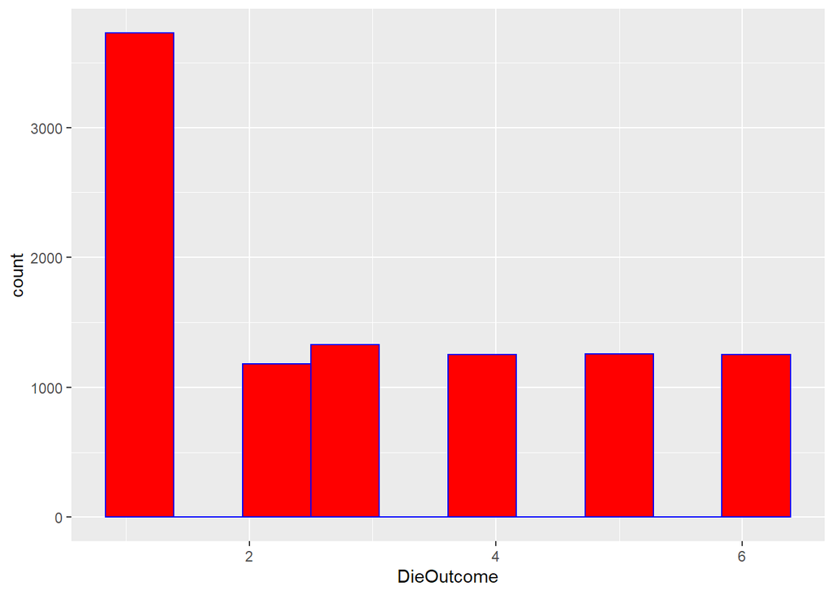

```r
set.seed(123)
# Simulate rolling the unfair die 10000 times
die_sample <- function(sample_size) {
   sample(1:6, sample_size, replace = TRUE, prob = c(3 / 8, rep(1 / 8, 5)))
}
DieOutcome <- replicate(10000,
    die_sample(1),
    simplify = "matrix")
# plot the frequency of each outcome by drawing the histogram
ggplot(data.frame(DieOutcome), aes(x = DieOutcome)) +
    geom_histogram(bins = 10, fill = "RED", color = "BLUE")
```

## 1(b)

```r
set.seed(123) # same as in part (a)
xbar10 <- c()
xbar30 <- c()
xbar100 <- c()
xbar1000 <- c()
# generate 10000 samples of size 10, 30, 100, and 1000 respectively
for (identifier in 1:10000) {
    # calculate the means for each sample for different sample sizes
    xbar10 <- c(xbar10, mean(die_sample(10)))
    xbar30 <- c(xbar30, mean(die_sample(30)))
    xbar100 <- c(xbar100, mean(die_sample(100)))
    xbar1000 <- c(xbar1000, mean(die_sample(1000)))
} # for
xbar10 <- data.frame(xbar10)
xbar30 <- data.frame(xbar30)
xbar100 <- data.frame(xbar100)
xbar1000 <- data.frame(xbar1000)
```

## 1(c)

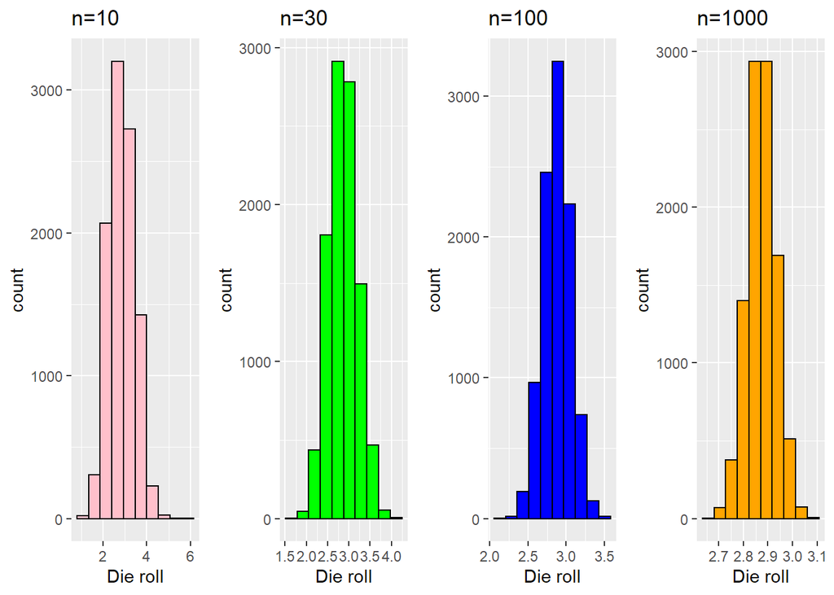

```r
plot.xbar10 <- ggplot(data.frame(xbar10), aes(x = xbar10)) +
    geom_histogram(bins = 10, fill = "PINK", color = "BLACK") +
        labs(x = "Die roll", title = "n=10")
plot.xbar30 <- ggplot(data.frame(xbar30), aes(x = xbar30)) +
    geom_histogram(bins = 10, fill = "GREEN", color = "BLACK") +
        labs(x = "Die roll", title = "n=30")
plot.xbar100 <- ggplot(data.frame(xbar100), aes(x = xbar100)) +
    geom_histogram(bins = 10, fill = "BLUE", color = "BLACK") +
        labs(x = "Die roll", title = "n=100")
plot.xbar1000 <- ggplot(data.frame(xbar1000), aes(x = xbar1000)) +
    geom_histogram(bins = 10, fill = "ORANGE", color = "BLACK") +
        labs(x = "Die roll", title = "n=1000")
plots_list <- list(plot.xbar10, plot.xbar30, plot.xbar100, plot.xbar1000)
grid.arrange(grobs = plots_list, ncol = 4)
```

### Compare these histograms based on their spread and explain the reason.

As the sample sizes get bigger (from 10 to 1000), the spread of the corresponding histograms becomes tighter. This is due to the variance in the sample means decreasing as sample size increases, which is in turn due to the Law of Large Numbers.

# Question 2

## 2(a)

```r
# Import this data in R using a suitable function
newdata <- read.csv(
    "X:/Downloads - Data Drive/Countries.csv",
    na.strings = "."
)
# Remove all these missing values
data <- remove_missing(newdata)
```

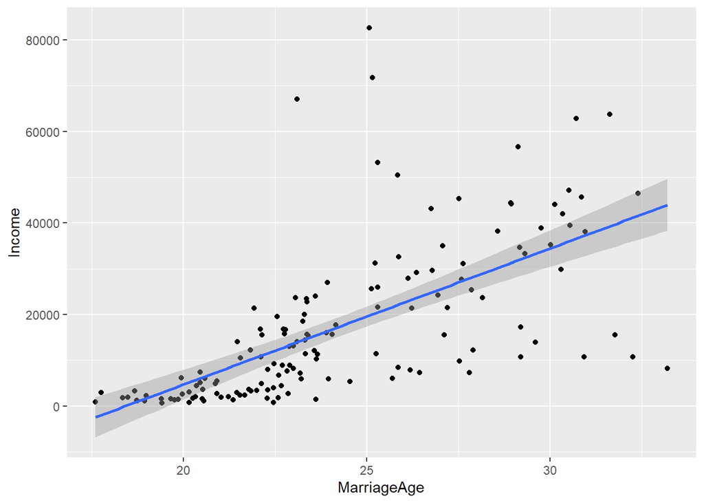

```r
# Draw a scatterplot to predict the Income based on the Marriage age
ggplot(data, aes(x = MarriageAge, y = Income)) +
    geom_point() +
    geom_smooth(method = "lm")
```

### Do you see any pattern? Comment on it.

I see a pattern where the dots of the scaterplot “snake” in an obvious way back and forth across the regression line.

## 2(b)

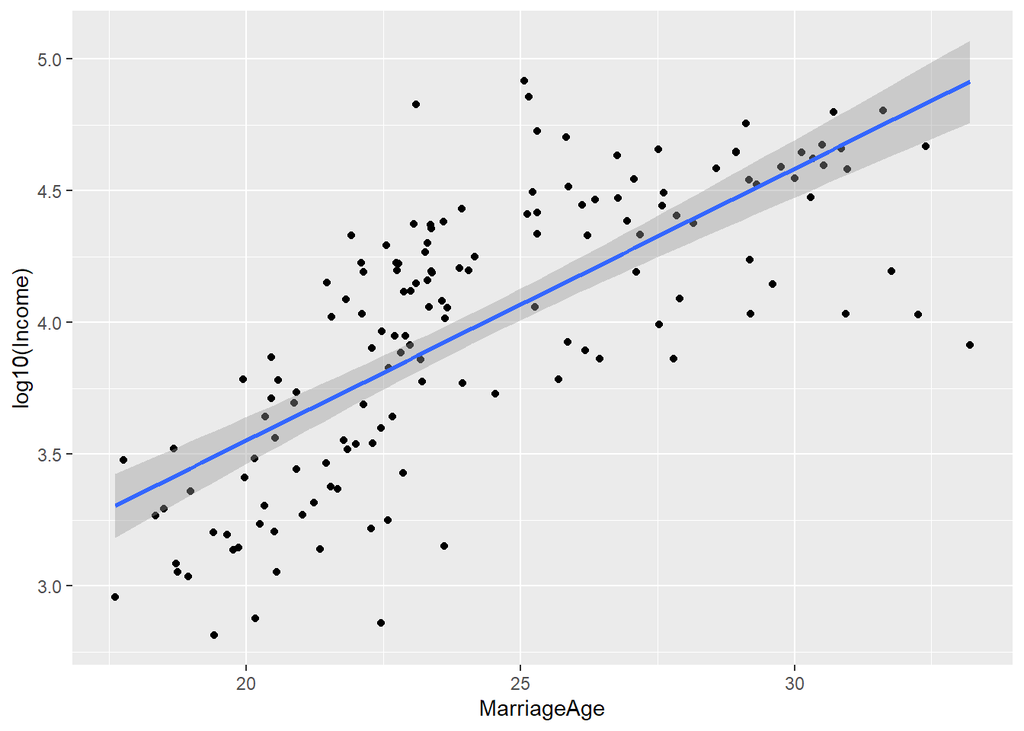

```r
# Produce a scatterplot using the log (base 10) Income variable
# versus the Marriage age
ggplot(data, aes(x = MarriageAge, y = log10(Income))) +
    geom_point() +
    geom_smooth(method = "lm")
```

### Comment on any pattern.

Compared to before (without logarithm transformation), this scatterplot looks a lot more randomly scattered.

### Would you prefer the plot in part (a) or part (b)

In predicting the Income with a linear model, i would prefer the plot in part (b) simply because it looks a lot linear (i.e., follows the overlaid regression line) more, whereas the plot in part (a) appears to have a more curvy shape.

## 2(c)

```r
# Fit a linear regression model for the plot you choose
linear_fitted_data <- lm(log10(Income) ~ MarriageAge, data) %>%
# Print the output
    print
```

```
##
## Call:
## lm(formula = log10(Income) ~ MarriageAge, data = data)
##
## Coefficients:
## (Intercept)  MarriageAge
##      1.4883       0.1032
```

## 2(d)

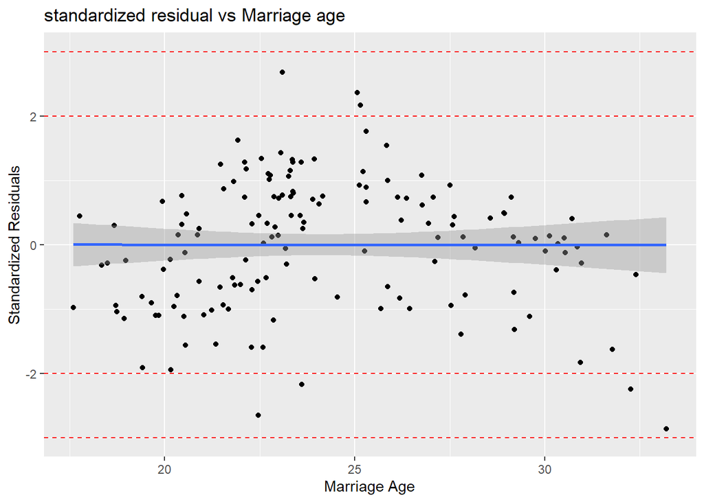

```r
# Calculate the standardized residual from the model you chose
s_residual <- rstandard(linear_fitted_data)
# Plot this standardized residual vs Marriage age
ggplot(data.frame(s_residual), aes(x = data$MarriageAge, y = s_residual)) +
    geom_point() +
    geom_smooth(method = "lm") +
    # Add a horizontal line at the points -3,-2,2,3
    geom_hline(yintercept = c(-3, -2, 2, 3), lty = "dashed", color = "RED") +
    labs(
        x = "Marriage Age",
        y = "Standardized Residuals",
        title = "standardized residual vs Marriage age"
    )
```

```r
# Find which standardized residual is the largest
# and the corresponding standardized residual value
# Print the output
which.max(abs(s_residual))
```

```
## 87
## 67
```

```r
s_residual[which.max(abs(s_residual))]
```

```
##        87
## -2.863772
```

# Question 3

## 3(a)

```r
pnorm(
    q = 24.1,
    mean = 24.1,
    sd = 6.30
) - pnorm(
    q = 19.2,
    mean = 24.1,
    sd = 6.30
)
```

```
## [1] 0.28165
```

## 3(b)

```r
qnorm(
    p = 0.14,
    mean = 24.1,
    sd = 6.30,
    lower.tail = FALSE
) %>%
    print
```

```
## [1] 30.90601
```

## 3(c)

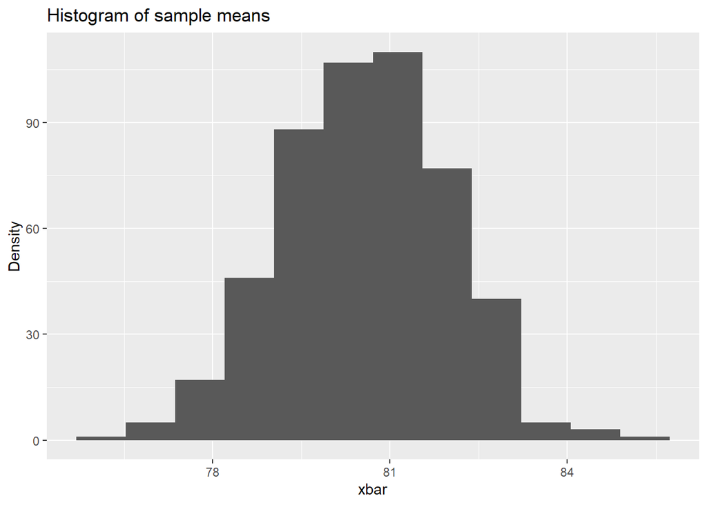

```r
# Find the mean of x
x <- c(70, 75, 78, 80, 85, 90, 95)
p_x <- c(0.25, 0.08, 0.11, 0.14, 0.17, 0.19, 0.06)
mean_x <- geometry::dot(x, p_x, d = TRUE)
# Generate 500 samples of size 30 from the x with replacement
# Calculate the mean of each sample
set.seed(120)
xbar <- replicate(500, mean(sample(x, 30, replace = TRUE, prob = p_x)))
# Draw the histogram of these 500 sample means
ggplot(data.frame(xbar), aes(x = xbar)) +
    geom_histogram(bins = 12) +
    labs(y = "Density", title = "Histogram of sample means")
```

### Comment on the shape of the histogram. Explain the reason.

The histogram is mound-shaped, since it’s denser near the center and less dense near the edges. This could be the result of there being more than 30 replicated sample means, which by the CLT, explains the shape.